# Phyloseq: BIOME Worshop

## Phyloseq

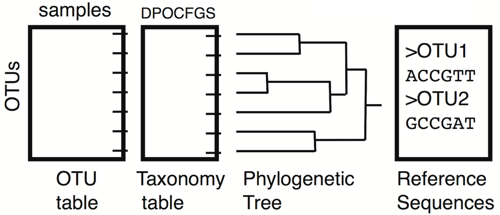

## Phyloseq Benefits

- phyloseq organizes the various types of data associated with metabarcoding projects, and keeps them consistent.
- phloseq has convenient interfaces with other useful R packages (ggplot2, vegan, ape, DESeq2,…)

## Phyloseq manipulation

1. Descriptors
2. Accessors
3. Subsetting
4. Transformations

## Load phyloseq

```r
library(phyloseq)
```

For completeness, here is the version number of phyloseq used to build this instance of the tutorial – and also how you can check your own current version from the command line.

```r
packageVersion("phyloseq")
```

```
## [1] '1.25.2'
```

## Load GlobalPatterns phyloseq object

Load the `GlobalPatterns` dataset, included with the phyloseq package.

```r
data("GlobalPatterns")
ps <- GlobalPatterns # For shorthand convenience
GlobalPatterns
```

```
## phyloseq-class experiment-level object
## otu_table()   OTU Table:         [ 19216 taxa and 26 samples ]
## sample_data() Sample Data:       [ 26 samples by 7 sample variables ]
## tax_table()   Taxonomy Table:    [ 19216 taxa by 7 taxonomic ranks ]
## phy_tree()    Phylogenetic Tree: [ 19216 tips and 19215 internal nodes ]
```

## Descriptors

## Experiment summaries

Phyloseq offers several ways to get global summaries of the information in a metabarcoding experiment.

Number of “taxa”.

```r
ntaxa(GlobalPatterns)
```

```
## [1] 19216
```

Number of samples.

```r
nsamples(GlobalPatterns)
```

```
## [1] 26
```

Names of the taxonomic ranks.

```r
rank_names(GlobalPatterns)
```

```
## [1] "Kingdom" "Phylum"  "Class"   "Order"   "Family"  "Genus"   "Species"
```

The variables defined in the sample (meta)data.

```r
sample_variables(GlobalPatterns)
```

```
## [1] "X.SampleID"               "Primer"
## [3] "Final_Barcode"            "Barcode_truncated_plus_T"
## [5] "Barcode_full_length"      "SampleType"
## [7] "Description"
```

The output when printing the object also contains most of these summaries.

## Names

The names of each sample and each “taxa” can be accessed from a phyloseq object, and changed as well.

```r
sample_names(GlobalPatterns)[1:5]
```

```
## [1] "CL3"     "CC1"     "SV1"     "M31Fcsw" "M11Fcsw"
```

```r
taxa_names(GlobalPatterns)[1:10]
```

```
##  [1] "549322" "522457" "951"    "244423" "586076" "246140" "143239"
##  [8] "244960" "255340" "144887"
```

In general, numbers make for bad names as they can get automatically and unexpectedly converted from strings to numbers, at which point they stop acting as names and start acting as indices. We will rename these taxa.

```r
## Easy way
#taxa_names(GlobalPatterns) <- paste("OTU", taxa_names(GlobalPatterns), sep="_")
## Robust way
taxa_names(GlobalPatterns) <- paste("OTU", gsub("^OTU_", "", taxa_names(GlobalPatterns)), sep="_")
taxa_names(GlobalPatterns)[1:10]
```

```
##  [1] "OTU_549322" "OTU_522457" "OTU_951"    "OTU_244423" "OTU_586076"
##  [6] "OTU_246140" "OTU_143239" "OTU_244960" "OTU_255340" "OTU_144887"
```

## Sample Abundances

One of the first things it is useful to look at is the distribution of abundances (or library sizes) of each sample.

```r
sample_sums(GlobalPatterns)
```

```
##      CL3      CC1      SV1  M31Fcsw  M11Fcsw  M31Plmr  M11Plmr  F21Plmr
##   864077  1135457   697509  1543451  2076476   718943   433894   186297
##  M31Tong  M11Tong LMEpi24M SLEpi20M   AQC1cm   AQC4cm   AQC7cm      NP2
##  2000402   100187  2117592  1217312  1167748  2357181  1699293   523634
##      NP3      NP5  TRRsed1  TRRsed2  TRRsed3     TS28     TS29    Even1
##  1478965  1652754    58688   493126   279704   937466  1211071  1216137
##    Even2    Even3
##   971073  1078241
```

Typically it is more useful to see this in a graphical form.

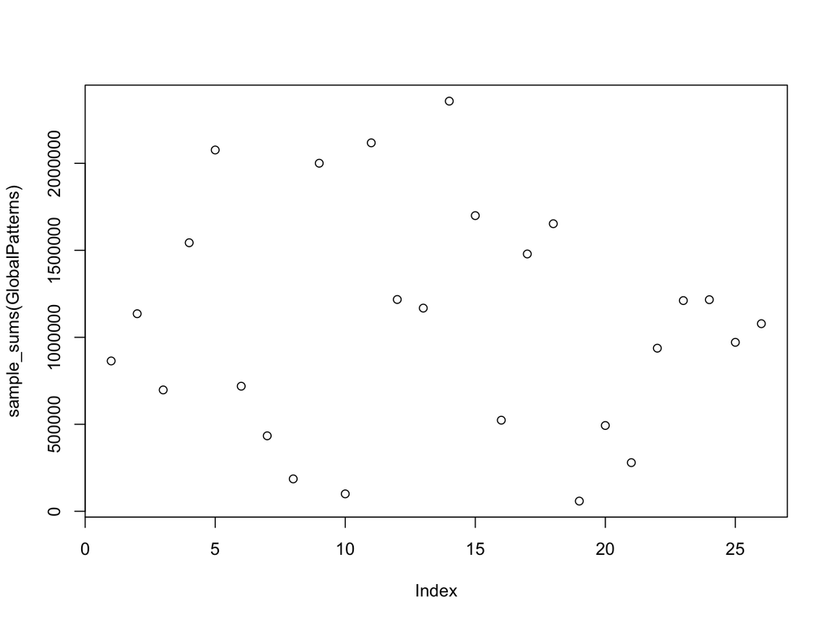

```r
plot(sample_sums(GlobalPatterns))
```

I often prefer the sorted view:

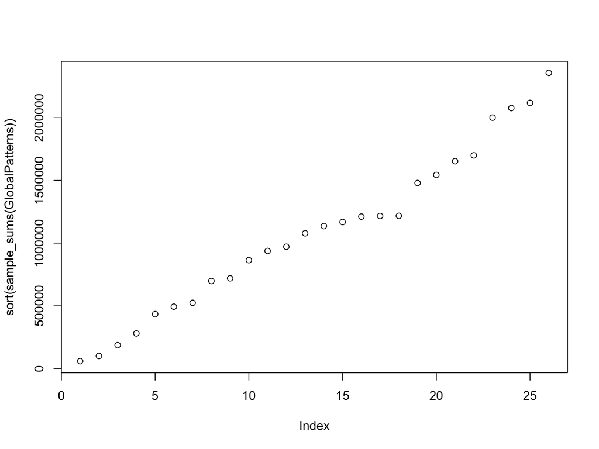

```r
plot(sort(sample_sums(GlobalPatterns)))
```

## Taxa Abundances

A similar function exists for exploring the abundances of each “taxa”.

```r
taxa_sums(GlobalPatterns)[1:10]
```

```
## OTU_549322 OTU_522457    OTU_951 OTU_244423 OTU_586076 OTU_246140
##        259          8          1         51          3          4
## OTU_143239 OTU_244960 OTU_255340 OTU_144887
##         11          1        352          8
```

```r
summary(taxa_sums(GlobalPatterns))
```

```
##    Min. 1st Qu.  Median    Mean 3rd Qu.    Max.
##       0       4      27    1468     198 2481214
```

Plotting taxonomic abundances on a log-scale is often useful.

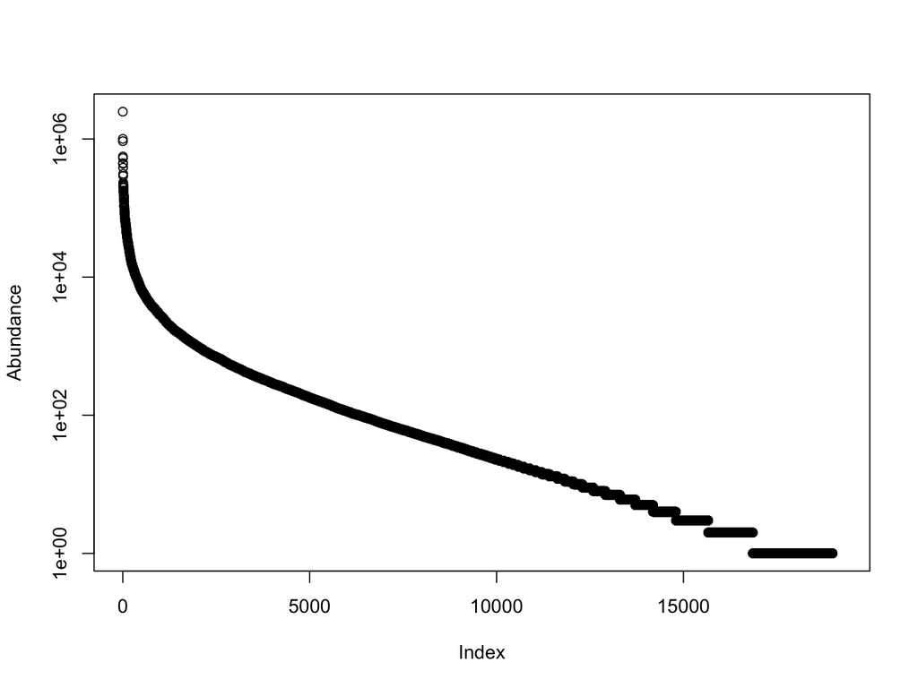

```r
sorted.sums <- sort(taxa_sums(GlobalPatterns), decreasing=TRUE)
plot(sorted.sums, log="y", ylab="Abundance")
```

Another useful metric is the cumulative amount of all reads in the top XX taxa.

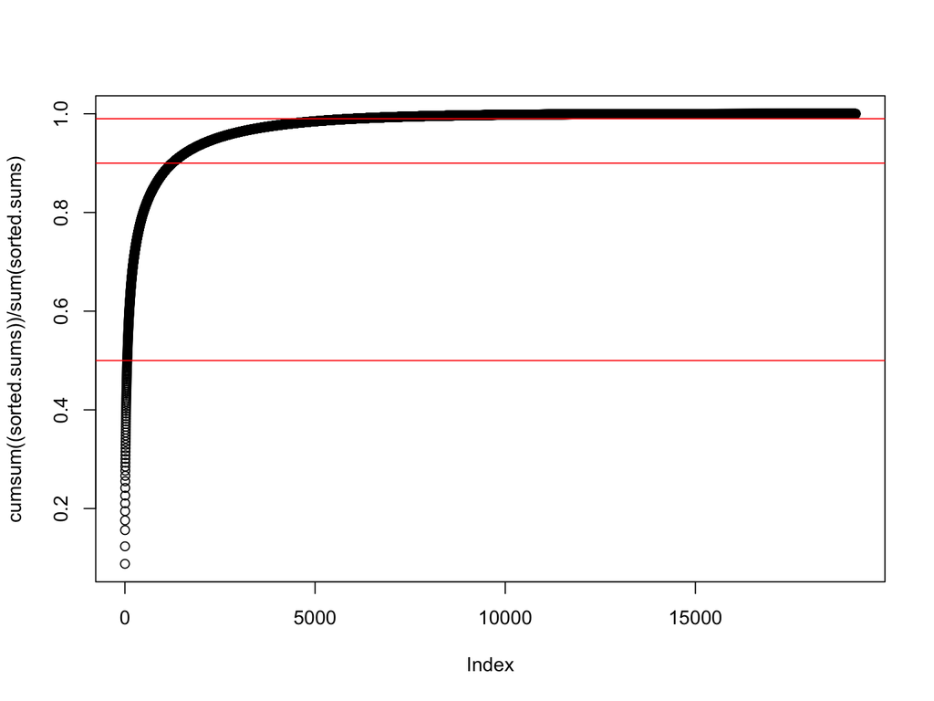

```r
plot(cumsum((sorted.sums))/sum(sorted.sums))
abline(0.5, 0, col="red")
abline(0.9, 0, col="red")
abline(0.99, 0, col="red")
```

## Accessors: “OTU” table

Components of a phyloseq object, like the OTU Table, can be accessed by special accessor functions, or ``accessors’’, which return specific information about the phylogenetic sequencing data, if present. These accessor functions are available for direct interaction by users and dependent functions/packages.

```r
otu_table(GlobalPatterns)[1:5, 1:5]
```

```
## OTU Table:          [5 taxa and 5 samples]
##                      taxa are rows
##            CL3 CC1 SV1 M31Fcsw M11Fcsw
## OTU_549322   0   0   0       0       0
## OTU_522457   0   0   0       0       0
## OTU_951      0   0   0       0       0
## OTU_244423   0   0   0       0       0
## OTU_586076   0   0   0       0       0
```

It is often useful to wrap these accessors in functions coercing them back into standard R objects.

```r
otu_mat <- function(ps) as(otu_table(ps), "matrix")
otu_mat(GlobalPatterns)[1:5, 1:5]
```

```
##            CL3 CC1 SV1 M31Fcsw M11Fcsw
## OTU_549322   0   0   0       0       0
## OTU_522457   0   0   0       0       0
## OTU_951      0   0   0       0       0
## OTU_244423   0   0   0       0       0
## OTU_586076   0   0   0       0       0
```

## Accessors: Sample (Meta)data

We can also pull out the sampe metadata and work with it directly.

```r
sample_df <- function(ps) as(sample_data(ps), "data.frame")
head(sample_df(GlobalPatterns))
```

```
##         X.SampleID  Primer Final_Barcode Barcode_truncated_plus_T
## CL3            CL3 ILBC_01        AACGCA                   TGCGTT
## CC1            CC1 ILBC_02        AACTCG                   CGAGTT
## SV1            SV1 ILBC_03        AACTGT                   ACAGTT
## M31Fcsw    M31Fcsw ILBC_04        AAGAGA                   TCTCTT
## M11Fcsw    M11Fcsw ILBC_05        AAGCTG                   CAGCTT
## M31Plmr    M31Plmr ILBC_07        AATCGT                   ACGATT
##         Barcode_full_length SampleType
## CL3             CTAGCGTGCGT       Soil
## CC1             CATCGACGAGT       Soil
## SV1             GTACGCACAGT       Soil
## M31Fcsw         TCGACATCTCT      Feces
## M11Fcsw         CGACTGCAGCT      Feces
## M31Plmr         CGAGTCACGAT       Skin
##                                        Description
## CL3       Calhoun South Carolina Pine soil, pH 4.9
## CC1       Cedar Creek Minnesota, grassland, pH 6.1
## SV1     Sevilleta new Mexico, desert scrub, pH 8.3
## M31Fcsw    M3, Day 1, fecal swab, whole body study
## M11Fcsw   M1, Day 1, fecal swab, whole body study
## M31Plmr    M3, Day 1, right palm, whole body study
```

We can then index into this just like a regular `data.frame`.

```r
sample_df(GlobalPatterns)$SampleType
```

```
##  [1] Soil               Soil               Soil
##  [4] Feces              Feces              Skin
##  [7] Skin               Skin               Tongue
## [10] Tongue             Freshwater         Freshwater
## [13] Freshwater (creek) Freshwater (creek) Freshwater (creek)
## [16] Ocean              Ocean              Ocean
## [19] Sediment (estuary) Sediment (estuary) Sediment (estuary)
## [22] Feces              Feces              Mock
## [25] Mock               Mock
## 9 Levels: Feces Freshwater Freshwater (creek) Mock ... Tongue
```

## Accessors: Taxonomy table and phylogenetic tree

Similar methods exist for the other two slots in a phyloseq object.

```r
tax_mat <- function(ps) as(tax_table(ps), "matrix")
tax_mat(GlobalPatterns)[1:5, ]
```

```
##            Kingdom   Phylum          Class          Order
## OTU_549322 "Archaea" "Crenarchaeota" "Thermoprotei" NA
## OTU_522457 "Archaea" "Crenarchaeota" "Thermoprotei" NA
## OTU_951    "Archaea" "Crenarchaeota" "Thermoprotei" "Sulfolobales"
## OTU_244423 "Archaea" "Crenarchaeota" "Sd-NA"        NA
## OTU_586076 "Archaea" "Crenarchaeota" "Sd-NA"        NA
##            Family          Genus        Species
## OTU_549322 NA              NA           NA
## OTU_522457 NA              NA           NA
## OTU_951    "Sulfolobaceae" "Sulfolobus" "Sulfolobusacidocaldarius"
## OTU_244423 NA              NA           NA
## OTU_586076 NA              NA           NA
```

```r
tre <- phy_tree(GlobalPatterns)
tre
```

```
##
## Phylogenetic tree with 19216 tips and 19215 internal nodes.
##
## Tip labels:
##  OTU_549322, OTU_522457, OTU_951, OTU_244423, OTU_586076, OTU_246140, ...
## Node labels:
##  , 0.858.4, 1.000.154, 0.764.3, 0.995.2, 1.000.2, ...
##
## Rooted; includes branch lengths.
```

## Accessors: Assignment

These accessor objects not only allow you to extract data from a phyloseq object, they also allow you to assign data to a phyloseq object. This is most often useful for the sample metadata, as you add more columns generated by additional analyses.

```r
# Assign the full sample_data
samdf <- sample_df(GlobalPatterns)
samdf$LibrarySize <- sample_sums(GlobalPatterns)
sample_data(GlobalPatterns) <- sample_data(samdf)
# The shorthand way, assign one column
sample_data(GlobalPatterns)$LibrarySize <- sample_sums(GlobalPatterns)
head(sample_df(GlobalPatterns))
```

```
##         X.SampleID  Primer Final_Barcode Barcode_truncated_plus_T
## CL3            CL3 ILBC_01        AACGCA                   TGCGTT
## CC1            CC1 ILBC_02        AACTCG                   CGAGTT
## SV1            SV1 ILBC_03        AACTGT                   ACAGTT
## M31Fcsw    M31Fcsw ILBC_04        AAGAGA                   TCTCTT
## M11Fcsw    M11Fcsw ILBC_05        AAGCTG                   CAGCTT
## M31Plmr    M31Plmr ILBC_07        AATCGT                   ACGATT
##         Barcode_full_length SampleType
## CL3             CTAGCGTGCGT       Soil
## CC1             CATCGACGAGT       Soil
## SV1             GTACGCACAGT       Soil
## M31Fcsw         TCGACATCTCT      Feces
## M11Fcsw         CGACTGCAGCT      Feces
## M31Plmr         CGAGTCACGAT       Skin
##                                        Description LibrarySize
## CL3       Calhoun South Carolina Pine soil, pH 4.9      864077
## CC1       Cedar Creek Minnesota, grassland, pH 6.1     1135457
## SV1     Sevilleta new Mexico, desert scrub, pH 8.3      697509
## M31Fcsw    M3, Day 1, fecal swab, whole body study     1543451
## M11Fcsw   M1, Day 1, fecal swab, whole body study      2076476
## M31Plmr    M3, Day 1, right palm, whole body study      718943
```

You can do similar things with the `otu_table` and `tax_table` and `phy_tree` slots.

## Subsetting: Samples

The key functions here are `subset_samples` and `prune_samples`.

`subset_samples` is based on the `subset` function from the data.table package, and allows you to specify a subsetting expression based on the sample variables.

```r
nsamples(GlobalPatterns)
```

```
## [1] 26
```

```r
foo <- subset_samples(GlobalPatterns, LibrarySize > 1000000)
nsamples(foo)
```

```
## [1] 14
```

```r
foo <- subset_samples(GlobalPatterns, LibrarySize > 1000000 & SampleType=="Soil")
nsamples(foo)
```

```
## [1] 1
```

Just 1 soil sample with >1M reads.

`prune_samples` is based on the user providing either the names of samples they want to *keep*, or a logical vector indicating (with TRUE) the samples they want to *keep*.

```r
foo <- prune_samples(sample_sums(GlobalPatterns) > 1000000, GlobalPatterns)
nsamples(foo)
```

```
## [1] 14
```

Both can be used to achieve the same thing. Use whichever is more convenient. Note that these functions keep everything *consistent*, that is they subset or prune samples from both the `otu_table` and the `sample_data` in the same way.

## Subsetting: Taxa

The key functions here are `subset_taxa` and `prune_taxa`. Their operation is exactly analogous to the `_samples` functions, with the difference being that the `tax_table` replaces the `sample_data` for the operatin of `subset_taxa`.

```r
ntaxa(GlobalPatterns)
```

```
## [1] 19216
```

```r
foo <- subset_taxa(GlobalPatterns, Phylum == "Bacteroidetes")
ntaxa(foo)
```

```
## [1] 2382
```

```r
foo <- prune_taxa(tax_mat(GlobalPatterns)[,"Phylum"] == "Bacteroidetes" & taxa_sums(GlobalPatterns) > 100, GlobalPatterns)
ntaxa(foo)
```

```
## [1] 845
```

`prune_taxa` is more widely useful, because `subset_taxa` is limited to operations using the taxonomic classifications. Note that these functions keep everything *consistent*, that is they subset or prune taxa from the `otu_table`, `tax_table` and `phy_tree` in the same way.

## Subsetting: Taxa Example

Here is an example of how one can inspect the phylogenetic tree of the 10 most abundant taxa in the dataset.

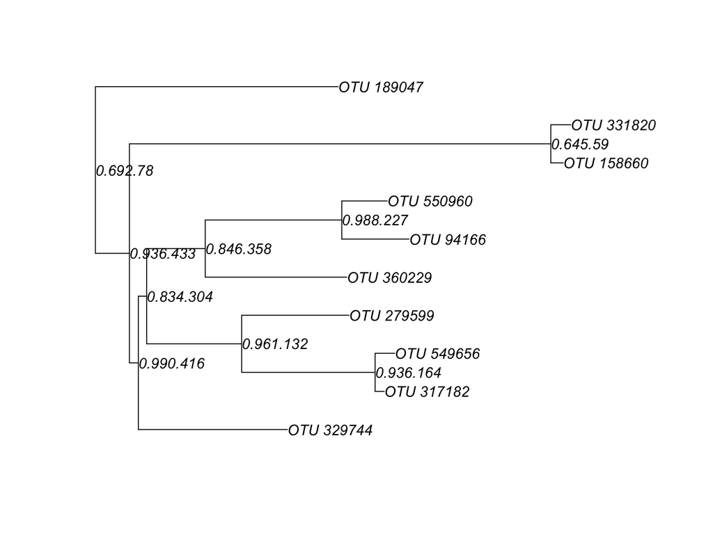

```r
top10.taxa = names(sort(taxa_sums(GlobalPatterns), decreasing = TRUE)[1:10])
ex1 = prune_taxa(top10.taxa, GlobalPatterns)
plot(phy_tree(ex1), show.node.label = TRUE)
```

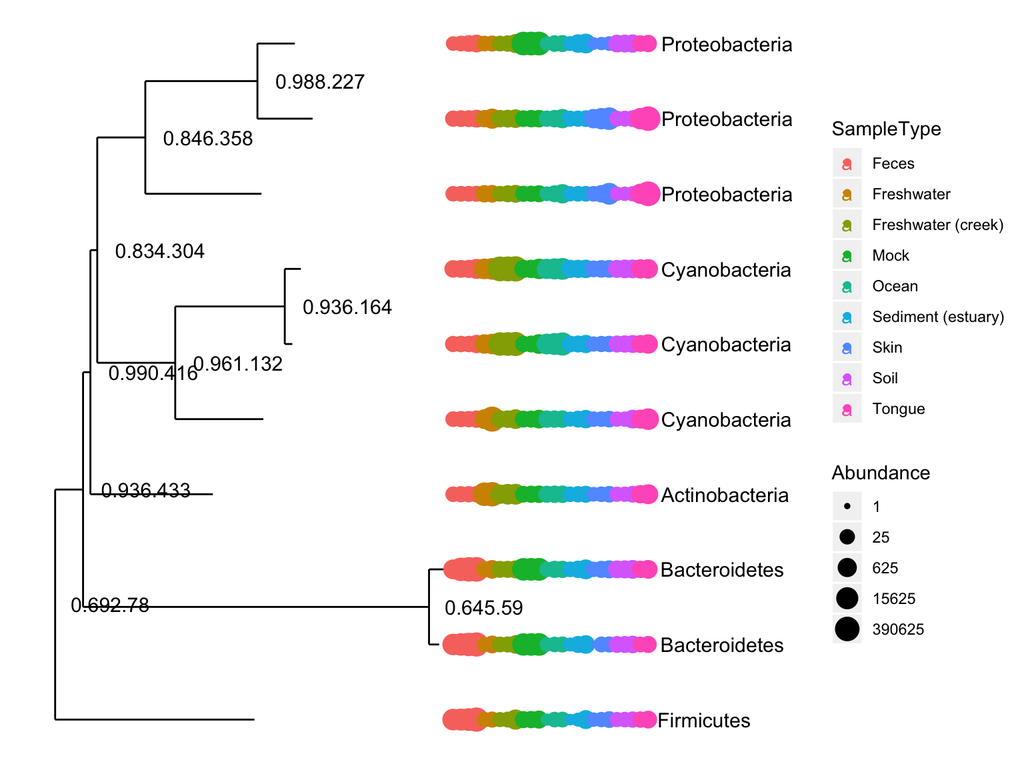

```r
plot_tree(ex1, color = "SampleType", label.tips = "Phylum", ladderize = "left", justify = "left" , size = "Abundance")
```

## Transformations: Abundances

One of the key statistical techniques for analyzing metabarcoding survey data (or any data) are data transformations. For example, one of the most common such transformations that is performed is to convert count data (e.g. of read) to proportions by dividing by the total number of reads in each sample. This functionality, in general form, is provided by the `transform_sample_counts` function.

Transform to proportions.

```r
GPr <- transform_sample_counts(GlobalPatterns, function(x) x / sum(x) )
# The function provided is applied to the vector of counts from each sample
```

Many other transformations are possible, for example the regularized log count.

```r
GPrlog <- transform_sample_counts(GlobalPatterns, function(x) log(1 + x) )
# rarefy_even_depth(...) can be used for the rarefaction approach.
```

There is much discussion on the right ways to normalized metabarcoding data. See for example the [“Waste Not, Want Not paper…”" by McMurdie and Holmes](https://doi.org/10.1371/journal.pcbi.1003531), or [“Normalization…strategies depend upon data characteristics” by Weiss et al](https://doi.org/10.1186/s40168-017-0237-y).

## Transformations: Taxa

```r
GPb <- subset_taxa(GlobalPatterns, Phylum=="Bacteroidetes")
GPb.fam = tax_glom(GPb, "Family")
plot_tree(GPb.fam, color="SampleType", label.tips = "Family")
```

[output not shown]

## Phyloseq manipulations

As you start chaining the subsetting, accessors, and transformations together, you can start doing some very powerful things, while letting phyloseq take care of the problem of keeping the different data types from your metabarcoding consistent with one another!

I suggest allowing yourself to explore [the phyloseq website](https://joey711.github.io/phyloseq/) for a bounty of documentation and example workflows.